# Data Science, Séance 1 : introduction

Etienne Côme

21 novembre 2019

## Data Science ?

*The next sexy job*

*The ability to take data to be able to understand it, to process it, to extract value from it, to visualize it, to communicate it, that’s going to be a hugely important skill.*

**– Hal Varian, Google**

## Data Science ?

*Data science, as it’s practiced, is a blend of Red-Bull-fueled **hacking** and espresso-inspired **statistics**.*

*Data science is the civil engineering of data. Its acolytes possess a practical knowledge of tools & materials, coupled with a theoretical understanding of what’s possible*

**– Mike Driscoll, CEO of metamarkets**

## Drew Conway’s Data Science Venn Diagram

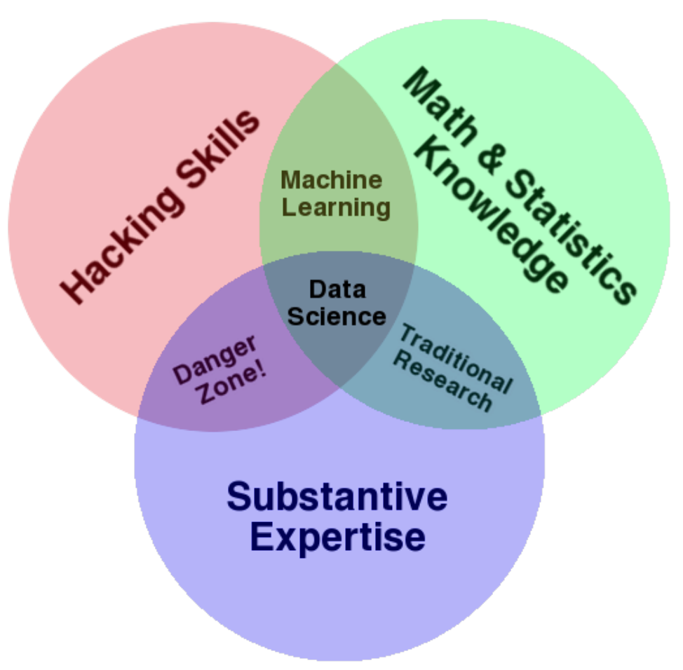

## Data Science ?

*A data scientist is someone who can obtain, scrub, explore, model and interpret data, blending hacking, statistics and machine learning. Data scientists not only are adept at working with data, but appreciate data itself as a first-class product.*

**– Hilary Mason, chief scientist at bit.ly**

## Data Science ?

*Parler de la donnée, c’est aussi évoquer le datascientist, ce mouton à 5 pattes de la data disposant de compétences statistiques, informatiques, comprenant parfaitement les enjeux métier de l’entreprise… Est-il aussi un fantasme du discours ambiant sur le big data ?*

*S’il peut exister des profils qui s’approchent de cette description, la réalité démontre le plus souvent que la datascience, comme la science en générale, ne se produit pas seule mais en groupe. La bonne question à se poser est donc plutôt celle de la synchronisation des différentes compétences au sein de l’organisation. Nous plaidons davantage pour un datascientism que pour des datascientists.*

*Une autre réalité méconnue sur le datascientist est qu’il s’agit avant tout d’un métier d’artisan. Chaque problème et chaque jeu de données demande toujours une démarche spécifique qui n’est pas industrialisable, ce que beaucoup de gens ne comprennent pas encore.*

## Une mode avec des origines anciennes

[figure not shown]

[Johann Kepler](http://fr.wikipedia.org/wiki/Johannes_Kepler)

## Une mode avec des origines anciennes

[figure not shown]

[Charles Joseph Minard](https://en.wikipedia.org/wiki/Charles_Joseph_Minard)

## Une mode avec des origines anciennes

[figure not shown]

[Charles Joseph Minard](https://en.wikipedia.org/wiki/Charles_Joseph_Minard)

## Une mode avec des origines anciennes

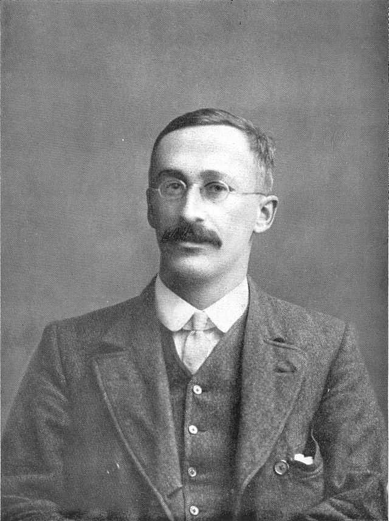

[William Sealy Gosset (Student)](https://en.wikipedia.org/wiki/William_Sealy_Gosset)

## Des compétences clés

### 1. Préparer les données (DB)

Récupérer, mélanger, enrichir, filtrer, nettoyer, vérifier, formater, transformer des données…

### 2. Mettre en œuvre une méthode un modèle (ML/Stats)

Arbre de décision, régression, clustering, Modèle graphique, SVM…

### 3. Interpréter les résultats (Vis)

Graphiques, Data visualisation, Cartes…

## Des compétences clés

### 1. Préparer les données (DB) – 80% du boulot

Récupérer, mélanger, enrichir, filtrer, nettoyer, vérifier, formater, transformer des données…

### 2. Mettre en œuvre une méthode un model (ML/Stats)

Arbre de décision, régression, clustering, Modèle graphique, SVM…

### 3. Interpréter les résultats (Vis) – 80% du boulot

Graphiques, Data visualisation, Cartes…

## Des compétences clés

### 1. Data Munging

Récupérer, mélanger, enrichir, filtrer, nettoyer, vérifier, formater, transformer des données

### 2. Statistiques

Analyse de données traditionnelle

### 3. Visualisation

Graphiques, Data visualisation, Cartes…

## Plan du cours

### Data-munging

- les fichiers textes csv, json, xml, … et la ligne de commande
- base de donnée et algèbre relationnel
- trouver des données, et les manipuler en R
- manipuler des données en R avec dplyr
- api, web et scraping, …
- données spatiale

### Visualisation

- introduction à la visualisation, bonnes pratiques & erreurs communes
- ggplot et la grammaire graphique
- introduction à la cartographie avec le package cartography

# Quelques exemples de projets

#### http://www.comeetie.fr/map_lbc.php

# Quelques exemples de projets

#### http://www.comeetie.fr/galerie/francepixels/

# Quelques exemples de projets

#### http://www.comeetie.fr/galerie/francepixels/

# Quelques exemples de projets

[figure not shown]

#### http://vlsstats.ifsttar.fr/

# Quelques exemples de projets

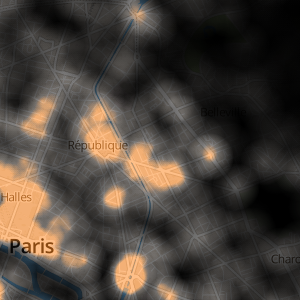

#### http://vlsstats.ifsttar.fr/atNight/

# Quelques exemples de projets

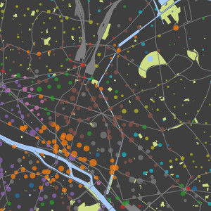

#### http://www.comeetie.fr/galerie/velib/

## Organisation du cours

### Cours orienté pratique et mise en œuvre

### Outils principaux : linux, R et Chrome

### Exercices de mise en oeuvre pratique

### + projet

### + contrôle continu

## Projet, foot data

- Données : https://figshare.com/collections/Soccer_match_event_dataset/4415000/2

## Quelques pointeurs

- Dépot web du cours : https://github.com/comeetie/dsp5.git
- Mon adresse mail : etienne.come@ifsttar.fr
- Mon compte twitter : [@comeetie](http://www.twitter.com/comeetie)
- Outils en ligne : [Google](http://www.google.com),[StackOverflow](http://www.StackOverflow.com), [gitHub](http://www.github.com), github.io
- Cours intéressants : [Stat221 (Harvard)](http://harvarddatascience.com/2013/02/20/introduction-to-computing-modeling-and-visualization-first-lectures-of-stat-221/), [CS294-10 (Berkley)](http://vis.berkeley.edu/courses/cs294-10-sp11/wiki/index.php/CS294-10_Visualization)

## Reprise en douceur avec des fondamentaux

### fichiers textes et ligne de commande

## Fichiers textes

Formats très simples et pérenne pour stocker des données et les échanger  
Exemples :

#### CSV : Comma Separated Value

#### XML : Extensible Markup Language

#### JSON : JavaScript Object Notation

## Les fichiers type csv

Fichier texte simple pour stocker des données tabulaire.  
Les différentes variables sont séparées grâce à une

### ‘,’ ou autre ‘;’, ‘|’, ‘#’ et ’

Possible de mettre une ligne pour le header

#### Exemple

```
"id" "mbikestands"
16104 30.5303867403315
15063 5.19337016574586
17010 16.2651933701657
13045 8.48066298342541
10025 9.31491712707182
...
```

## Compétence : Savoir importer un fichier malgré des problèmes d’encodage et/ou de formatage

## La ligne de commande

#### obtenir de l’aide

man

#### rediriger les sorties

[<, >, >>, …](http://fr.wikipedia.org/wiki/Interface_en_ligne_de_commande#Les_redirections_d.27entr.C3.A9es.2Fsorties)

#### enchainer des commandes

| et [script bash](http://fr.wikipedia.org/wiki/Bourne-Again_shell)

#### afficher un fichier

head, tail, cat et more

## La ligne de commande

#### analyser le fichier

[grep](http://fr.wikipedia.org/wiki/Grep) : global regular expression  
Filtrer toute les lignes contenant ‘tot’

```c
grep tot fichier.txt
```

Filtrer toute les lignes contenant un chiffre de 0 à 4 suivi d’un nombre quelconque de caractères et d’un chiffre de 5 à 9

```c
grep '[01234].*[56789]' fichier.txt
```

Filtrer toute les lignes commençant par un tirer

```c
grep '^-' fichier.txt
```

options -i, -n et -c,…

## La ligne de commande

#### éditer le fichier

nano et gedit

#### modifier, analyser le fichier

[sed](http://fr.wikipedia.org/wiki/Stream_Editor) : stream editor (lecture ligne/ligne)  
remplacer toutes les occurrences de “ficheir” par “fichier” :

```c
sed -e 's/ficheir/fichier/g' fichier.txt > fichier.corrected.txt
```

supprimer toutes les lignes vides :

```c
sed -e '/^ *$/d' fichier.txt
```

supprimer les lignes 7 à 9 :

```c
sed '7,9d' fichier.txt
```

## La ligne de commande

#### modifier, analyser le fichier

[perl](http://fr.wikipedia.org/wiki/Stream_Editor) : practical extraction and reporting language  
substitution multiples et mise en mémoire des pattern matchés:

```c
 perl -pe 's/last_update":([0-9]*)}/last_update":0000$1}/g'
```

## La ligne de commande

#### problème d’encodage

[file](http://en.wikipedia.org/wiki/Iconv) : informations sur un fichier

```c
file -i fichier.txt -o fichier.utf8
```

[iconv](http://en.wikipedia.org/wiki/Iconv) : changement d’encodage  
iso-8859 → utf8

```c
iconv -f ISO-8859-1 -t UTF-8 fichier.txt -o fichier.utf8
```

## Import en R de fichiers type csv

#### problème de formatage et import dans R

```r
data = read.table(...)
```

- ! au séparateur de champs
- ! à l’en-tête
- ! au conversion de chaîne de caractère en facteur
- ! au séparateurs décimaux : , ou .
- ! au séparateurs de chaîne de caractère " ou ’ ?

## Exercice (20 mn) :

#### Importer proprement dans R le fichier ./data/exo1.csv qui contient des problèmes d’encodage et de formatage avec read.table

#### Vérifier que les variables numériques sont bien numériques, que les chaines de caractères sont bien des chaines de caractères ….

#### Même chose avec read_csv de la library readr

## Compétence : Savoir lire et remettre en forme un fichier JSON en R

## Package Rjson

#### Lecture ecriture de JSON

lire un fichier [JSON](http://fr.wikipedia.org/wiki/JavaScript_Object_Notation) :

```r
 data=fromJSON(file="fichier.json")
```

exporter un objet R en [JSON](http://fr.wikipedia.org/wiki/JavaScript_Object_Notation) :

```r
 toJSON(data)
```

manipuler :

```r
apply(data,function(x){})
unlist(list)
```

## Exercice (20mn):

Créer la data.frame suivante :

```
"id" "mbikestands"
"1" 16104 30.5303867403315
"2" 15063 5.19337016574586
"3" 17010 16.2651933701657
"4" 13045 8.48066298342541
...
```

qui contient les id des stations velib et la moyenne du nombre de bornes disponibles sur la période enregistrée.  
Pour cela vous utiliserez le fichier ./data/exo2.json qui à la forme suivante :  
tableau de stations ayant chacune une id (id) et trois tableaux associés; nombre de vélos (available_bikes), nombre de bornes (available_bike_stands), date de la mesures (download_date)

## Les fichiers type XML

- Fichier texte contenant des balises imbriquées
- Chaque balise peut être décrite par différents attributs
- Les balises et attributs devraient être décrit par une *dtd* et/ou des *namespaces*

#### Parser un fichiers

2 méthodes :

- SAX: api pour la lecture en ligne d’un document récupération d’évènements correspondant à la lecture d’une balise particulière
- DOM: méthode de construction de l’arbre DOM du document

## Exemple

```xml
<?xml version='1.0' encoding='UTF-8'?>
<stations lastUpdate="1409819465886" version="2.0">
<station>
    <id>2</id>
    <name>Dézery/Ste-Catherine</name>
    <terminalName>6002</terminalName>
    ...
</station>
<station>
    <id>3</id>
    <name>St-Maurice/ St-Henri</name>
    <terminalName>6003</terminalName>
    ...
</station>
</stations>
```

## Package XML

- permet de parser un fichier et de construire un arbre DOM
- fournis des fonctions pour parcourir et extraire les données de l’arbre créer

#### Exemple d’utilisation

```r
data   = xmlTreeParse("exo3.xml") # parser le fichier
xmltop = xmlRoot(data) # recupérer la racine
child  = xmlChildren(xmltop) # les fils
child2 = xmlValue(child) # les valeurs
val2   = xmlValue(child2)
res1   = xmlSapply(xmltop,xmlValue) # appliquer une fonction
```

## Exercice (20mn)

#### Construire à partir du fichier ./data/exo3.xml une data.frame contenant les variables suivantes :

#### ‘id’,‘lat’,‘long’,‘nbBikes’,‘nbEmptyDocks’

## Correction

```r
library(XML)
data     = xmlTreeParse("./data/exo3.xml") # parser le fichier
stations = xmlChildren(xmlRoot(data)) # liste des stations
vars = c('id','lat','long','nbBikes','nbEmptyDocks')
resMatrix=sapply(stations,function(x){
  # extraction des variables
  clist = lapply(xmlChildren(x),xmlValue)
  # sélection des variables
  sel   = names(clist) %in% vars
  # et conversion des variables
  as.numeric(unlist(clist[sel]))
  })
# mise sous forme de data.frame
res=data.frame(t(resMatrix),row.names = NULL)
names(res)=c('id','lat','long','nbBikes','nbEmptyDocks')
```